# annie

A Package for Artificial Neural Networks

# 1 **Introduction**

The human brain is one of the wonders of the world. We can effortlessly recognize any familiar animal like a dog or a cat. The primary visual cortex containing millions of neurons is responsible for this. Artificial neural networks (ANNs) are the result of the goal to develop computational equivalents of neurons for perceptual recognition. Artificial neural networks have been successfully used in supervised learning and unsupervised learning tasks. We consider the task of classification using supervised learning to understand the architecture of the ANN.

Given the input variables or features (X) and the class label or output variable(Y), the task of learning the mapping function between inputs and outputs is referred to as supervised learning. Given a labelled dataset ANNs can learn non-linear and complex mapping functions. It is essential to understand what a perceptron [1] is before understanding neural networks.

## 1.1 **Perceptron / Neuron**

Perceptron was first introduced by Frank Rosenblatt (1958), inspired by previous work by Warren McCulloch and Walter Pitts. The perceptron consists of a single neuron which takes several inputs x1, x2,.., and produces a binary output. Figure 1 shows a perceptron which takes three inputs x1, x2, x3 and computes one binary output.

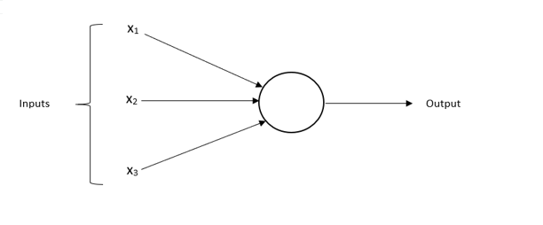

**Figure 1.** Perceptron

The perceptron can have any number of inputs. All the inputs are given weights w1, w2, â¦, which express the importance of the input to the output. All the weights are real numbers. The output y is computed as follows:

$$\begin{equation}
y =
\begin{cases}
0 & \text{if } \sum{w_i x_i} \leq \text{threshold} \\
1 & \text{if } \sum{w_i x_i} > \text{threshold}
\end{cases}
\end{equation}$$

A threshold is a real number which is a parameter of the neuron. The perceptron is a linear classifier which means it classifies data points or patterns which are linearly separable.

## 1.2 **Artificial Neural Networks**

Artificial neural network also known as multi-layer perceptron (MLP) is a network of artificial neurons arranged in different layers. ANNs are made up of three kinds of layers, an input layer, one or more hidden layers, and an output layer. Figure 2 shows a simple neural network with an input layer, one hidden layer, and an output layer. The architecture of the ANN shown in Figure 2 consists of only one hidden layer but there can be more than one hidden layer in a neural network.

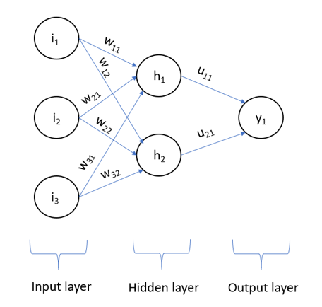

The neurons in the network are also referred to as units. Each layer is made up of neurons or units. The number of units in the input layer depends on the number of features or attributes of the tuple. Similarly, the number of units in the output layer depends on the number of class labels. One neuron or unit is used in the output layer for a binary classification task.

The neural network in Figure 2 is also known as a fully connected feed forward network where every unit in input layer and hidden layer is connected to every unit in the layer next to it. This may not be the case with all the architectures. Each connection has a weight associated with it. The input to the network is fed simultaneously to the input layer. The inputs pass through the units in the input layer and are then weighted and fed simultaneously to the units in the hidden layer. The outputs of the units in hidden layer can be input to the units in the next hidden layer, and so on. The outputs of the units in the last hidden layer are weighted. They are then input to the units in the output layer, which gives the neural networkâs prediction for given input. The units in the input layer are called input units. The units in the hidden layers and output layer are also referred to as output units.

The weighted sum of the outputs from units in the previous layer is the input to the output units. Then an activation function (nonlinear) is applied to the weighted input. Sigmoid, ReLU and Tanh are some of the popular choices for activation functions. Artificial neural networks have the capability to perform nonlinear modeling.

During the training phase the weights in the network is initialized with small random numbers. The inputs are then fed to the input layer. The inputs pass through the input layer without any change. The net input to each unit in hidden layer is computed by multiplying the weight associated with each input connected to the current unit and this is summed. Then the bias is added. Given a unit, k in a hidden or output layer, the net input, $I_k$, to unit $k$ is

$$\begin{equation}
I_k = \sum_{i}{w_{ij} O_i}
\end{equation}$$

where $w_{ij}$ is the weight associated with the connection from unit $i$ in the previous layer; $O_i$ is the output of unit i from the previous layer. Then each unit applies activation function to the net input and this output is further propagated forward to successive layers. The output layer gives the networkâs prediction. The classification error is calculated by the mean squared error between the value predicted by the network and the actual known target value. The objective is to reduce classification error. Backpropagation algorithm [2] is used to reduce the classification error.

# 2 **Methods**

There are a total of 12 functions in the `annie` package. Some of these functions help in pre-processing the data, some implement the neural network and some help in evaluating the performance of the neural network. The list of functions with their short descriptions is as follows:

| Function | Description |
| --- | --- |
| `ttsplit(x, y, fraction)` | Split the data into training and testing datasets. |
| `normalize(x)` | Normalize skewed data before training neural network. |
| `rand_init(L_in, L_out, epsilon.init)` | Randomly initialize weight matrices while implementing symmetry breaking. |
| initiate_theta(x, y, layers, hidden.units, …) | Randomly initialize the weight matrices for a neural network. |
| `sigmoid(m)` | Evaluate element-wise sigmoid function of a matrix. |
| `sigmoidgradient(m)` | Evaluate the gradient of the sigmoid function. |
| forwardpass(x, y, layers, hidden.units, lambda, th.vec, …) | Implements the neural network with an initial set of weights, calculates the error and backpropagates the error through the neural network. |
| costfunction(x, y, layers, hidden.units, lambda, th.vec, …) | Cost function of the neural network for a given set of weights. |
| costfunctiongrad(x, y, layers, hidden.units, lambda, th.vec, …) | Gradient of cost function evaluated with respect to each weight. |
| nnlearn(x, y, layers, hidden.units, w, lambda = 0, …) | Function to train a neural network. |
| `nnpredict(weights, x.new, y.train)` | Predict labels for new feature data. |
| `diagnostics(predictions, y.test)` | Evaluate performance parameters of a neural network. |

**Table 1.** List of functions in the `annie` package

The `annie` package conducts all calculations using vectorized implementation rather than using loops. This is done in the interest of saving time and increasing efficiency. From this, it is implicit that the data passed into `annie`âs functions (`x, y, theta.vec, w` etc.) must be in matrix or vector form. One drawback of this approach is that it decreases the readability of the code to anyone who is not very familiar with the neural network algorithm, a small price to pay for efficiency.

## 2.1 **Test-Train Split :** `ttsplit(x, y, fraction)`

`ttsplit()` Function samples random indices and creates sub datasets for training and testing from the original complete dataset. `ttsplit()` uses `sample()` from Râs base package to randomly pick indices for the training and testing sets. The value of fraction determines the size of the training set as compared to the size of the full dataset. If the value of fraction in unspecified, it takes on the default value 0.66.

`ttsplit()` returns a list of four matrices.  
`x.train` â The subset of x to be used for training.  
`y.train` â The subset of y to be used for training.  
`x.test` â The subset of x to be used for testing.  
`y.test` â The subset of y to be used for testing.

## 2.2 **Normalization :** `normalize(x)`

Often times, the data that one would like to use is skewed. One solution of this issue is to normalize the data before using it. `normalize()` takes in the data as a matrix and returns a matrix of the same size with the normalized data. `normalize()` uses the following transformation to normalize data.

$$\begin{equation}
x_{norm} = \frac{x_i - \mu_i}{\sigma_i}
\end{equation}$$

## 2.3 **Matrix Random Initialization :** `rand_init(L_in, L_out, epsilon.init)`

`rand_init()` creates matrices of random valued elements based on L_in and L_out which are the sizes of the layers just before and just after the layer in question. These matrices go on to serve as the initial weight matrices of the neural network. The phrase random initialization suggests that the matrix can be filled with any random values. But, the inclusion of random extreme values will cause erroneous optimization and may cause the optimization algorithm to converge at a local minimum rather than the global minimum. `rand_init()` uses epsilon.init to employ symmetry breaking. The output of `rand_init()` is a matrix of size `(L_out) x (1+L_in)`.

## 2.4 **Random Initialization of Weights :** `initiate_theta(x, y, layers, hidden.units, …)`

`initiate_theta()` randomly initializes weight matrices for the whole neural network. `initiate_theta()` calls the `rand_init()` function in order to randomly initialize individual matrices. `initiate_theta()` deduces the input and output layer sizes from x and y. layers is the number of hidden layers in the input and hidden.units is the number of neurons in each layer. The output of `initiate_theta()` is a list of size `(layers+1)` which contains the randomly initialized weight matrices.

## 2.5 **Sigmoid :** `sigmoid(m)`

`annie` uses the sigmoid function as the default activation function in each neuron. `sigmoid()` applies the sigmoid function to each element of the input matrix `m`. The output of `sigmoid(m)` is a matrix of the same size as `m`. The formula for the sigmoid function is as follows:

$$\begin{equation}
sigmoid(z) = \frac{1}{1+e^{-z}}
\end{equation}$$

## 2.6 **Gradient of Sigmoid :** `sigmoidgradient(m)`

`sigmoidgradient()` calculates the gradient of the sigmoid function. This gradient has a very significant role in the backpropagation part of the neural network algorithm. `sigmoidgradient()` calls the `sigmoid(m)` function. `sigmoidgradient(m)` returns a matrix of the same size as m. Gradient of the sigmoid function is calculated as follows.

$$\begin{equation}
\frac{d(sigmoid(z))}{dz} = sigmoid(z).(1-sigmoid(z))
\end{equation}$$

## 2.7 **Feed Forward and Backpropagation :** `forwardpass(x, y, layers, hidden.units, lambda, th.vec, …)`

`forwardpass()` takes in data, weights and architecture of the neural network and deploys the neural network in feed forward. At the end of the feed forward implementation, `forwardpass()` calculates the errors and implements backpropagation. `forwardpass()` returns a list which contains the matrix containing the probabilities i.e. the hypothesis matrix, value of the cost function and gradient of the cost function evaluated at each weight parameter.

## 2.8 **Cost Function :** `costfunction(x, y, layers, hidden.units, lambda, th.vec, …)`

`costfunction()` calls the `forwardpass()` function and isolates the value of the cost function.

## 2.9 **Gradient of Cost Function :** `costfunctiongrad(x, y, layers, hidden.units, lambda, th.vec, …)`

`costfunctiongrad()` calls the `forwardpass()` function and isolates the gradients of the cost function calculated with respect to each weight parameter.

## 2.10 **Training of NeuralNetwork :** `nnlearn(x, y, layers, hidden.units, w, lambda = 0, …)`

`nnlearn()` is the function used to train the neural network. `nnlearn()` calls the `optim()` function and attempts to minimize cost function by using weights as the parameter. `nnlearn()` uses the conjugate gradient method– `CG` as the default optimization algorithm unless otherwise specified. `nnlearn()` implements unregularized training (`lambda = 0`) unless otherwise specified. `nnlearn()` returns a list containing the optimized weight matrices.

## 2.11 **Prediction of labels :** `nnpredict(weights, x.new, y.train)`

`nnpredict()` takes in new feature data and weights (usually obtained form `nnlearn()`) and predicts labels (`y`) corresponding to the new feature data. `nnpredict()` is the application after the neural network has been trained. `nnpredict()` is used to classify new data and also to test the performance of the algorithm.

## 2.12 **Performance Diagnostics :** `diagnostics(predictions, y.test)`

`diagnostics()` evaluates the performance of the neural network. It takes in the predictions made for the test set and compares the to the actual labels. `diagnostics()` returns a list consisting of âAccuracyâ and âFÂ¬1 Scoreâ. They are calculated as follows

$$\begin{equation}
Accuracy = \frac{\text{True Positives} + \text{True Negatives}}{\text{Total Predictions}}
\end{equation}$$

$$\begin{equation}
F_{1} Score = \frac{2(\text{Precision})(\text{Recall})}{\text{Precision}+\text{Recall}}
\end{equation}$$

Where,

$$\begin{equation}
Precision = \frac{\text{True Positives}}{\text{True Positives} + \text{False Positives}}
\end{equation}$$

$$\begin{equation}
Recall = \frac{\text{True Positives}}{\text{True Positives} + \text{False Negatives}}
\end{equation}$$

# 3 **Limitations**

The `annie` package has a few limitations which are listed below:

1. The data input must be in matrix/vector form. Future improvements to the `annie` package will attempt to have a formula style input.
2. `normalize()` will normalize all columns of the input matrix. There may be some features that do not need normalization. It is advised to eliminate these columns from the input matrix before passing it into `normalize()`.
3. The architecture of the neural network is determined by the variables `layers` and `hidden.units`. The architecture is such that each layer has the same number of neurons. This does not cause specific problems but it may end up increasing the computational cost of huge networks. Also, this means that networks formed by `annie` do not have a lot of structural flexibility.
4. At this moment, `annie` does not have the capability to optimize the regularization parameter. Regularization parameter has to be optimized separately by the user and then passed into `nnlearn()`.
5. `annie` does no have a built in default dataset.

# 4 **Results**

Edgar Anderson’s Iris Data contained within the `iris` will be used in this section to demonstrate the usage of the `annie` package.

`Speal.Length, Sepal.Width, Petal.Length` and `Petal.Width` will be used as features and `Species` will be the labels. The demonstration will begin by first loading the `annie` package.

```r
require("annie")
```

## 4.1 **Data-Import**

`iris` by default is in the form of a data frame. The function `data.matrix` converts a data frame into a numeric matrix. This also converts strings and categorical data into numerical data by assigning a numerical value to each category. In the resultant matrix, the first four columns will be used as feature data (x) and the last column will be used as label data (y).

```
##   Sepal.Length Sepal.Width Petal.Length Petal.Width Species
## 1          5.1         3.5          1.4         0.2  setosa
## 2          4.9         3.0          1.4         0.2  setosa
## 3          4.7         3.2          1.3         0.2  setosa
## 4          4.6         3.1          1.5         0.2  setosa
## 5          5.0         3.6          1.4         0.2  setosa
## 6          5.4         3.9          1.7         0.4  setosa
```

```
##      Sepal.Length Sepal.Width Petal.Length Petal.Width Species
## [1,]          5.1         3.5          1.4         0.2       1
## [2,]          4.9         3.0          1.4         0.2       1
## [3,]          4.7         3.2          1.3         0.2       1
## [4,]          4.6         3.1          1.5         0.2       1
## [5,]          5.0         3.6          1.4         0.2       1
## [6,]          5.4         3.9          1.7         0.4       1
```

## 4.2 **Pre-processing**

In pre-processing, data will be divided into training and testing sets first. For this demonstration, 70% of the data will be used as the training set and the reamining 30% for testing.

```r
nnd = ttsplit(xf,yf,fraction=0.7)
str(nnd)
```

```
## List of 4
##  $ x.train: num [1:105, 1:4] 7.7 5 5 4.9 6.7 4.9 6.2 6.3 6 7.6 ...
##   ..- attr(*, "dimnames")=List of 2
##   .. ..$ : NULL
##   .. ..$ : chr [1:4] "Sepal.Length" "Sepal.Width" "Petal.Length" "Petal.Width"
##  $ x.test : num [1:45, 1:4] 4.9 4.6 4.6 5.8 5.1 4.6 5 5.2 5.2 5.4 ...
##   ..- attr(*, "dimnames")=List of 2
##   .. ..$ : NULL
##   .. ..$ : chr [1:4] "Sepal.Length" "Sepal.Width" "Petal.Length" "Petal.Width"
##  $ y.train: num [1:105] 3 1 1 2 3 1 3 3 2 3 ...
##  $ y.test : num [1:45] 1 1 1 1 1 1 1 1 1 1 ...
```

After the separation, both sets of feature data will be normalized separately. It is important to normalize `iris` because all four features have different ranges.

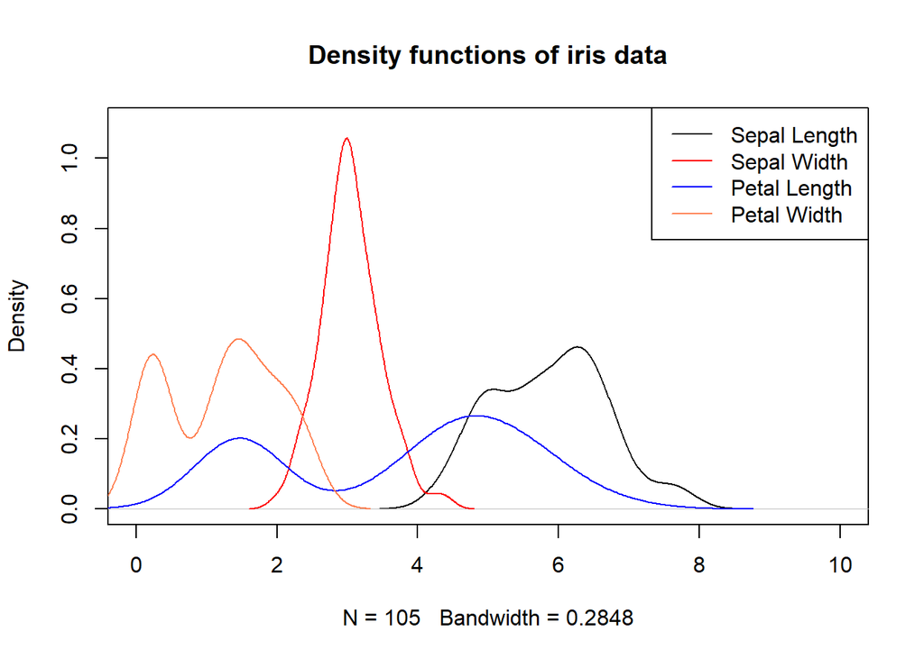

Figure 3. Density plots of features before normalization

Normalizing iris data,

```r
# Normalizing training data
xtr = normalize(xtr.un)
# Normalizing testing data
xts = normalize(xts.un)
```

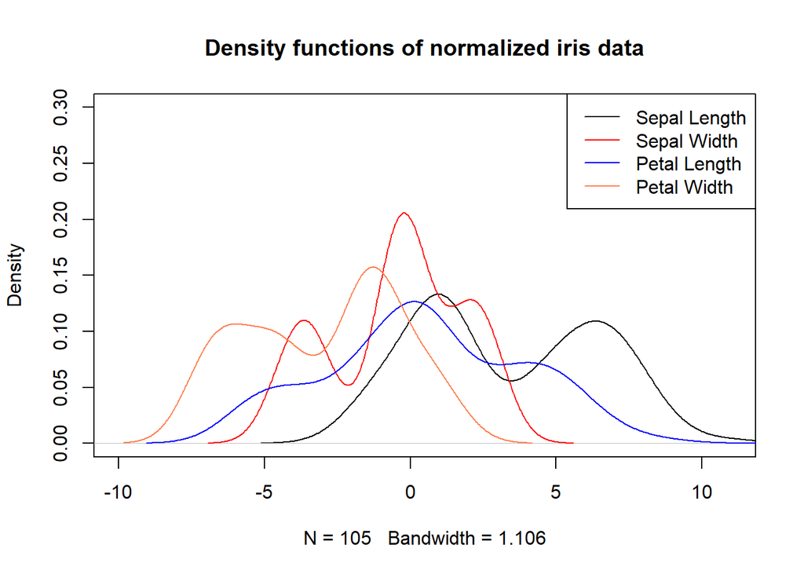

## 4.3 **Neural Network Training**

The neural netowrk can be trained using the pre-processed data and just the `nnlearn()` function. Most of the functions listed in the previous section are internal and the userneed not use them separately. But this report will include the demonstration of each function for better uderstanding of the algorithm.

First, `rand_init` will be demonstrated with a input layer size 4 and output layer size 5.

```r
set.seed(123)
(rand.mtx = rand_init(4,5))
```

```
##            [,1]        [,2]       [,3]         [,4]      [,5]
## [1,] -1.7317495  1.98419281  1.1824206  2.101520352 -2.560245
## [2,] -1.1923748 -0.06382357 -0.2289231 -0.003510154 -1.172448
## [3,]  1.7288634 -2.88233293 -0.1620395 -4.027968950 -2.491955
## [4,] -0.7013569 -1.93812259 -0.6357525  0.328812810 -2.006771
## [5,] -0.6053706 -1.54425953 -1.7241814 -1.588561717 -1.837181
```

For this demonstration, a neural network with two hidden layers containing 5 neurons each will be used i.e. `layers = 2` and `hidden.units = 5`. The data being used in the normalized iris data. The weight matrices will now be randomly initialized.

```r
set.seed(95)
w.rand = initiate_theta(xtr,ytr,2,5)
print(w.rand,digits =3)
```

```
## [[1]]
##        [,1]   [,2]  [,3]   [,4]   [,5]
## [1,] -2.497  0.321  1.61 -0.606 -4.493
## [2,] -3.455 -2.229  1.69 -4.754  1.136
## [3,] -0.862 -2.572  1.56 -3.728 -0.376
## [4,] -1.341  0.807 -2.24 -0.845  3.066
## [5,]  2.254 -1.192 -3.72 -2.302 -1.049
##
## [[2]]
##        [,1]    [,2]   [,3]   [,4]   [,5]   [,6]
## [1,]  0.777 -1.8404  0.747 -0.667  0.121 -0.872
## [2,] -2.497 -3.7396  0.207  1.081  1.047 -1.316
## [3,]  0.031  0.4532  0.465  0.962 -0.810 -2.414
## [4,] -0.500 -0.2993 -0.672  0.615 -0.455  0.628
## [5,]  1.751 -0.0811 -0.220  1.342 -4.275  1.245
##
## [[3]]
##        [,1]  [,2]   [,3]  [,4]    [,5]    [,6]
## [1,] -0.386 -1.98 -2.156 -1.80 -0.0395 -0.5157
## [2,]  0.717  1.68 -0.356 -1.93 -1.4015 -2.7121
## [3,] -0.760 -4.14 -0.694 -1.51  2.7544  0.0375
```

- `w.rand[[1]]` is the weight matrix corresponding to the input layer and hidden layer 1.
- `w.rand[[2]]` is the weight matrix corresponding to hidden layer 1 and hidden layer 2.
- `w.rand[[3]]` is the weight matrix corresponding to hidden layer 2 and the output layer.

`sigmoid()` and `sigmoidgradient()` are internal functions in the subsequent methods. One must keep in mind that the following implementation of these functions have no bearing on the larger demonstration with `iris` data.

```
## sigmoid(m) =
```

```
##       [,1]  [,2]  [,3]  [,4]  [,5]
## [1,] 0.698 0.588 0.408 0.495 0.258
## [2,] 0.208 0.865 0.759 0.702 0.504
## [3,] 0.739 0.889 0.817 0.626 0.418
## [4,] 0.577 0.636 0.779 0.890 0.375
## [5,] 0.807 0.500 0.681 0.318 0.445
## [6,] 0.594 0.304 0.727 0.404 0.178
```

```
##
## sigmoidradient(m) =
```

```
##       [,1]   [,2]  [,3]   [,4]  [,5]
## [1,] 0.211 0.2423 0.242 0.2500 0.192
## [2,] 0.165 0.1168 0.183 0.2091 0.250
## [3,] 0.193 0.0984 0.150 0.2341 0.243
## [4,] 0.244 0.2315 0.172 0.0978 0.234
## [5,] 0.156 0.2500 0.217 0.2169 0.247
## [6,] 0.241 0.2117 0.199 0.2408 0.146
```

All the subsequent functions take in weights as input in the vector form. So, it is important to convert the list of weights into a vector.

Note: `nnlearn()` does the initialization and vectorization of weight matrices automatically and the user need not vectorize weights separately.

```r
w.vec = unlist(w.rand)
```

`forwardpass()` will now be called to implement feed forward and backpropagation parts of the algorithm. `forwardpass()` does not optimize the weights. Here, the regularization parameter `lambda` will be set to 0.05.

```r
fp = forwardpass(xtr,ytr,2,5, lambda = 0.05, th.vec = w.vec)
str(fp)
```

```
## List of 3
##  $ Hypothesis: num [1:105, 1:3] 0.2024 0.1519 0.1661 0.0693 0.2022 ...
##  $ Cost      : num 2.77
##  $ D         : num [1:73] -0.033594 -0.013803 0.005078 -0.000428 -0.013519 ...
```

`costfunction()` and `costfunctiongrad()` call `forwardpass()` and isolate the value of cost function and gradients of cost function respectively.

```r
J = costfunction(xtr,ytr,2,5,lambda = 0.05, th.vec = w.vec)
cat("Cost = ",J)
```

```
## Cost =  2.766757
```

```r
J.grad = costfunctiongrad(xtr,ytr,2,5,lambda = 0.05, th.vec = w.vec)
cat("Cost function gradients = \n\n",J.grad[1:5],"...")
```

```
## Cost function gradients =
##
##  -0.03359393 -0.01380325 0.005077692 -0.0004279712 -0.01351855 ...
```

Now, the `optim` function will be implemented separately from `nnlearn()` to arrive at a optimal set of weights.

```r
w.opt = optim(par=w.vec,fn=costfunction,x=xtr,y=ytr,layers=2,hidden.units=5,lambda=0.05,gr=costfunctiongrad,method="CG")
cat("Optimal weights = \n\n",w.opt$par[1:5],"...")
```

```
## Optimal weights =
##
##  -2.005898 -2.543541 -0.7608842 -1.598847 2.893588 ...
```

With this optimization, the neural network has been trained. `nnlearn()` will reshape these weights into usable matrices. Since, the internal working of the training algorithm has been explored, the demonstration will make use of the `nnlearn()` from this point on.

`nnlearn()` will now be used to train the neural network with the same architecture.

```r
nn.model = nnlearn(xtr,ytr,2,5,w=w.vec,lambda=0.05)
cat("Optimal weight matrices = \n\n")
```

```
## Optimal weight matrices =
```

```r
print(nn.model,digits=3)
```

```
## [[1]]
##        [,1]   [,2]  [,3]   [,4]    [,5]
## [1,] -2.006  1.649  1.23  0.729 -2.3304
## [2,] -2.544  0.577  3.06 -3.669  0.0849
## [3,] -0.761 -0.348  2.07 -2.179 -0.1003
## [4,] -1.599 -0.204 -1.27 -0.824  1.7136
## [5,]  2.894 -1.077 -2.06 -0.254  0.4097
##
## [[2]]
##        [,1]   [,2]   [,3]   [,4]    [,5]   [,6]
## [1,] -1.597 -2.041  4.780  2.888 -0.0412  0.165
## [2,] -2.555 -1.959  0.134  0.597  0.5466 -0.688
## [3,] -0.353  0.576 -0.305  0.169 -0.4580 -2.048
## [4,]  1.504  1.084 -3.667 -1.571 -0.2019 -0.211
## [5,]  3.114  0.653 -0.421  0.455 -2.2254  0.916
##
## [[3]]
##        [,1]  [,2]   [,3]  [,4]  [,5]   [,6]
## [1,] -0.482 -3.87 -1.136 -1.59  2.14 -0.909
## [2,]  0.143  6.52 -0.183 -1.01 -4.83 -1.281
## [3,] -1.462 -3.58 -0.347  1.18  2.24 -0.839
```

## 4.4 **Neural Network Testing**

Now that the neural network has been trained, it is time to test it. The testing datasets `xts` and `yts` will be used for this purpose.

`nnpredict()` takes in new feature data `x` and uses the optimized weight matrices to predict labels which it isolated from `y`.

```r
predictions = nnpredict(nn.model,xts,yts)
predictions
```

```
##  [1] 1 1 1 1 1 1 1 1 1 1 1 1 1 1 1 2 2 2 2 2 2 2 2 2 2 2 2 2 2 2 2 3 3 3 3
## [36] 3 3 3 3 3 3 3 3 3 3
```

`nnpredict()` took in 45 rows of feature data from `xts` and predicted 45 values corresponding to species of the flower.

It is always important to have real value numbers to measure the performance of a model. $Accuracy$ is a good measure for this purpose but it fails to capture the true performance of a model in problems where the label data is skewed. For instance, imagine a cancer detection problem where 1 out of 10 patients has cancer i.e. `y = 1` for one patient. A model which simply predicts `y = 0` will predict 9 out of 10 patients’ condition correctly i.e. will have an accuracy of 90% without even performing any calculations. It counter this fallacy, $F_1 Scores$ are used. `diagnostics()` calculates both accuracy and $F_1 Scores$.

```r
performance = diagnostics(predictions,yts)
performance
```

```
## $Accuracy
## [1] 93.33333
##
## $F1.scores
## [1] 0.9677419 0.8965517 0.9333333
```

These results show that the `annie` package can effectively train a neural network model and use it in conjunction with new data to make predictions. Further developments may include the capability to conduct image classification, optimizing regularization parameter and formula input from a data frame.

# 5 **References**

1. F. Rosenblatt, “The Perceptron : A Probabilistic model for information storage and organization in the brain,” Psychological Review, vol. 65, no. 6, pp. 386-408, 1958.
2. J. Han, Data mining Concepts and Techniques, Morgan Kaufman, 2011.